# ReCell Project

## Background

- ReCell is a startup aiming to tap the potential in the used and refurbished phone market that has grown considerably over the past decade.
- ReCell believes that the COVID-19 outbreak may further boost the demand for cheaper used smartphones as these devices continue to provide cost-effective alternatives to both consumers and businesses.
- However, since this is a relatively under-the-radar market, an attempt is being made to devise an ML-based solution to develop a dynamic pricing strategy for used and refurbished smartphones.
- A linear regression model is being built to predict the price of a used phone and identify factors that significantly influence it.

## Data Description

The dataset consists of the following variables:

- brand_name: Name of manufacturing brand
- os: OS on which the phone runs
- screen_size: Size of the screen in cm
- 4g: Whether 4G is available or not
- 5g: Whether 5G is available or not
- main_camera_mp: Resolution of the rear camera in megapixels
- selfie_camera_mp: Resolution of the front camera in megapixels
- int_memory: Amount of internal memory (ROM) in GB
- ram: Amount of RAM in GB
- battery: Energy capacity of the phone battery in mAh
- weight: Weight of the phone in grams
- release_year: Year when the phone model was released
- days_used: Number of days the used/refurbished phone has been used
- new_price: Price of a new phone of the same model in euros
- used_price: Price of the used/refurbished phone in euros

## Objectives

To explore the dataset and extract insights from it using **Exploratory Data Analysis** before building a model with it. More specifically, an attempt is being made to answer the following questions:

- What does the distribution of used phone prices look like?
- What percentage of the used phone market is dominated by Android devices?
- The amount of RAM is important for the smooth functioning of a phone. How does the amount of RAM vary with the brand?
- A large battery often increases a phone's weight, making it feel uncomfortable in the hands. How does the weight vary for phones offering large batteries (more than 4500 mAh)?
- Bigger screens are desirable for entertainment purposes as they offer a better viewing experience. How many phones are available across different brands with a screen size larger than 6 inches?
- Budget phones nowadays offer great selfie cameras, allowing us to capture our favorite moments with loved ones. What is the distribution of budget phones offering greater than 8MP selfie cameras across brands?
- Which attributes are highly correlated with the used phone price?

Furthermore, **preprocessing** the data to make it ready for analysis and modeling.

Finally, building a **Linear Regression Model** to guage the significance of predictors on the price of a used smartphone.

```python
# Importing the required libraries for reading and manipulating data for data analysis
import numpy as np
import pandas as pd

# Importing the required libraries for data visualization
import matplotlib.pyplot as plt
import seaborn as sns

# Tells python to display the graphs
%matplotlib inline

sns.set()

# Ensuring each plot has a nice background
sns.set(color_codes=True)

# This will help in making the Python code more structured automatically (good coding practice)
%load_ext nb_black

# Library to do away with warnings
import warnings

warnings.filterwarnings("ignore")

# To split the data into train and test
from sklearn.model_selection import train_test_split

# To build a linear regression_model
from sklearn.linear_model import LinearRegression

# To check the model performance
from sklearn.metrics import mean_absolute_error, mean_squared_error, r2_score

# To build the linear regression_model using statsmodels
import statsmodels.api as sm

# To be able to view 500 columns at once
pd.set_option("display.max_columns", 500)
```

```python
# Loading the ReCell Dataset
data = pd.read_csv("used_phone_data.csv")
```

```python
# Let's create a copy of the data to avoid any changes to original data
phone = data.copy()
```

## Data Overview

```python
# Viewing the first few rows of the dataset
phone.head()
```

|  | brand_name | os | screen_size | 4g | 5g | main_camera_mp | selfie_camera_mp | int_memory | ram | battery | weight | release_year | days_used | new_price | used_price |
| --- | --- | --- | --- | --- | --- | --- | --- | --- | --- | --- | --- | --- | --- | --- | --- |
| 0 | Honor | Android | 23.97 | yes | no | 13.0 | 5.0 | 64.0 | 3.0 | 3020.0 | 146.0 | 2020 | 127 | 111.62 | 86.96 |
| 1 | Honor | Android | 28.10 | yes | yes | 13.0 | 16.0 | 128.0 | 8.0 | 4300.0 | 213.0 | 2020 | 325 | 249.39 | 161.49 |
| 2 | Honor | Android | 24.29 | yes | yes | 13.0 | 8.0 | 128.0 | 8.0 | 4200.0 | 213.0 | 2020 | 162 | 359.47 | 268.55 |
| 3 | Honor | Android | 26.04 | yes | yes | 13.0 | 8.0 | 64.0 | 6.0 | 7250.0 | 480.0 | 2020 | 345 | 278.93 | 180.23 |
| 4 | Honor | Android | 15.72 | yes | no | 13.0 | 8.0 | 64.0 | 3.0 | 5000.0 | 185.0 | 2020 | 293 | 140.87 | 103.80 |

```python
# Viewing the last few rows of the dataset
phone.tail()
```

|  | brand_name | os | screen_size | 4g | 5g | main_camera_mp | selfie_camera_mp | int_memory | ram | battery | weight | release_year | days_used | new_price | used_price |
| --- | --- | --- | --- | --- | --- | --- | --- | --- | --- | --- | --- | --- | --- | --- | --- |
| 3566 | Asus | Android | 15.88 | yes | no | NaN | 8.0 | 64.0 | 6.0 | 5000.0 | 190.0 | 2019 | 232 | 654.5000 | 490.96 |
| 3567 | Asus | Android | 15.24 | yes | no | 13.0 | 8.0 | 128.0 | 8.0 | 4000.0 | 200.0 | 2018 | 541 | 518.8145 | 259.30 |
| 3568 | Alcatel | Android | 18.73 | yes | no | 13.0 | 5.0 | 32.0 | 3.0 | 4000.0 | 165.0 | 2020 | 201 | 92.6500 | 69.81 |
| 3569 | Alcatel | Android | 18.73 | yes | no | 13.0 | 5.0 | 32.0 | 2.0 | 4000.0 | 160.0 | 2020 | 149 | 101.9150 | 76.07 |
| 3570 | Alcatel | Android | 13.49 | yes | no | 13.0 | 5.0 | 16.0 | 2.0 | 4000.0 | 168.0 | 2020 | 176 | 72.2415 | 50.48 |

```python
# Looking at a ramdom sample of 10 rows
np.random.seed(1)
phone.sample(n=10)
```

|  | brand_name | os | screen_size | 4g | 5g | main_camera_mp | selfie_camera_mp | int_memory | ram | battery | weight | release_year | days_used | new_price | used_price |
| --- | --- | --- | --- | --- | --- | --- | --- | --- | --- | --- | --- | --- | --- | --- | --- |
| 2501 | Samsung | Android | 13.49 | yes | no | 13.0 | 13.0 | 32.0 | 4.00 | 3600.0 | 181.0 | 2017 | 683 | 198.680 | 79.47 |
| 2782 | Sony | Android | 13.81 | yes | no | NaN | 8.0 | 32.0 | 4.00 | 3300.0 | 156.0 | 2019 | 195 | 198.150 | 149.10 |
| 605 | Others | Android | 12.70 | yes | no | 8.0 | 5.0 | 16.0 | 4.00 | 2400.0 | 137.0 | 2015 | 1048 | 161.470 | 48.39 |
| 2923 | Vivo | Android | 19.37 | yes | no | 13.0 | 16.0 | 64.0 | 4.00 | 3260.0 | 149.3 | 2019 | 375 | 211.880 | 138.31 |
| 941 | Others | Others | 5.72 | no | no | 0.3 | 0.3 | 32.0 | 0.25 | 820.0 | 90.0 | 2013 | 883 | 29.810 | 8.92 |
| 1833 | LG | Android | 13.49 | no | no | 8.0 | 1.3 | 32.0 | 4.00 | 3140.0 | 161.0 | 2013 | 670 | 240.540 | 96.18 |
| 671 | Apple | iOS | 14.92 | yes | no | 12.0 | 7.0 | 64.0 | 4.00 | 5493.0 | 48.0 | 2018 | 403 | 700.150 | 350.08 |
| 1796 | LG | Android | 17.78 | yes | no | 5.0 | 0.3 | 16.0 | 4.00 | 4000.0 | 294.8 | 2014 | 708 | 189.300 | 75.94 |
| 757 | Asus | Android | 13.49 | yes | no | 13.0 | 8.0 | 32.0 | 4.00 | 5000.0 | 181.0 | 2017 | 612 | 270.500 | 108.13 |
| 3528 | Realme | Android | 15.72 | yes | no | NaN | 16.0 | 64.0 | 4.00 | 4035.0 | 184.0 | 2019 | 433 | 159.885 | 80.00 |

### Observations

- 4G and 5G availability has been depicted in terms of 'yes' and 'no'. These should be replaced with 1 and 0 respectively.
- As can be seen through a random sample of 10 observations, there seem to be null values in the data which will need to be treated.
- There seems to be widespread variation between new_price and used_price, something that will be explored further.
- 'used_price' is the dependent/target/response variable and all the others are independent/predictor/explanatory variables.

```python
# Checking the number of rows and columns in the dataset
phone.shape
```

```
(3571, 15)
```

- The dataset has 3571 rows and 15 columns.

```python
# Taking a look at the column names
phone.columns
```

```
Index(['brand_name', 'os', 'screen_size', '4g', '5g', 'main_camera_mp',
       'selfie_camera_mp', 'int_memory', 'ram', 'battery', 'weight',
       'release_year', 'days_used', 'new_price', 'used_price'],
      dtype='object')
```

```python
# check the number of unique values in each column of the dataframe
phone.nunique()
```

```
brand_name            34
os                     4
screen_size          127
4g                     2
5g                     2
main_camera_mp        44
selfie_camera_mp      37
int_memory            16
ram                   14
battery              354
weight               613
release_year           8
days_used            930
new_price           3099
used_price          3044
dtype: int64
```

```python
# Checking the data types and number of non-null values for each column
phone.info()
```

```
<class 'pandas.core.frame.DataFrame'>
RangeIndex: 3571 entries, 0 to 3570
Data columns (total 15 columns):
 #   Column            Non-Null Count  Dtype
---  ------            --------------  -----
 0   brand_name        3571 non-null   object
 1   os                3571 non-null   object
 2   screen_size       3571 non-null   float64
 3   4g                3571 non-null   object
 4   5g                3571 non-null   object
 5   main_camera_mp    3391 non-null   float64
 6   selfie_camera_mp  3569 non-null   float64
 7   int_memory        3561 non-null   float64
 8   ram               3561 non-null   float64
 9   battery           3565 non-null   float64
 10  weight            3564 non-null   float64
 11  release_year      3571 non-null   int64
 12  days_used         3571 non-null   int64
 13  new_price         3571 non-null   float64
 14  used_price        3571 non-null   float64
dtypes: float64(9), int64(2), object(4)
memory usage: 418.6+ KB
```

### Observations

- There are 3571 rows and 15 columns.
- There are 34 unique phone brands and 4 operating systems on which the phones run.
- 4g and 5g should have values 1(=yes) and 0(=no) and should be converted to category type.
- The dtype of 'release_year' must be converted into datetime format. Also, there appear to be 8 unique years in the given dataset.
- There are missing values in the data and imputation with median would be used later by defining a function for the same.

```python
# Checking the count of each unique 'brand_name'

uniqueb_col = ["brand_name"]  # Making a list

# Printing the count of each unique 'brand_name'
for column in uniqueb_col:
    print(phone[column].value_counts().sort_values(ascending=False))
```

```
Others        509
Samsung       364
Huawei        264
LG            212
Lenovo        172
ZTE           141
Xiaomi        134
Oppo          129
Asus          126
Alcatel       125
Nokia         121
Micromax      120
Honor         118
Vivo          117
Motorola      110
HTC           110
Sony           88
Meizu          62
Apple          59
Gionee         56
Acer           51
XOLO           49
Panasonic      47
Realme         41
Celkon         37
Lava           36
Karbonn        30
Spice          30
Microsoft      22
BlackBerry     22
Coolpad        22
OnePlus        22
Google         15
Infinix        10
Name: brand_name, dtype: int64
```

```python
# Replacing yes and no in column values with 1 & 0 respectively
phone["4g"] = phone["4g"].replace({"yes": 1, "no": 0})
phone["5g"] = phone["5g"].replace({"yes": 1, "no": 0})
```

```python
phone.info()
```

```
<class 'pandas.core.frame.DataFrame'>
RangeIndex: 3571 entries, 0 to 3570
Data columns (total 15 columns):
 #   Column            Non-Null Count  Dtype
---  ------            --------------  -----
 0   brand_name        3571 non-null   object
 1   os                3571 non-null   object
 2   screen_size       3571 non-null   float64
 3   4g                3571 non-null   int64
 4   5g                3571 non-null   int64
 5   main_camera_mp    3391 non-null   float64
 6   selfie_camera_mp  3569 non-null   float64
 7   int_memory        3561 non-null   float64
 8   ram               3561 non-null   float64
 9   battery           3565 non-null   float64
 10  weight            3564 non-null   float64
 11  release_year      3571 non-null   int64
 12  days_used         3571 non-null   int64
 13  new_price         3571 non-null   float64
 14  used_price        3571 non-null   float64
dtypes: float64(9), int64(4), object(2)
memory usage: 418.6+ KB
```

### Fixing the datatypes

```python
# Converting caterogical columns into categorical types

phone["brand_name"] = phone["brand_name"].astype("category")
phone["os"] = phone["os"].astype("category")
# phone["4g"] = phone["4g"].astype("category")
# phone["5g"] = phone["5g"].astype("category")
```

### Summary of the data

```python
# Let's look at the statistical summary of the data
phone.describe().T
```

|  | count | mean | std | min | 25% | 50% | 75% | max |
| --- | --- | --- | --- | --- | --- | --- | --- | --- |
| screen_size | 3571.0 | 14.803892 | 5.153092 | 2.700 | 12.700 | 13.49 | 16.510 | 46.36 |
| 4g | 3571.0 | 0.660599 | 0.473572 | 0.000 | 0.000 | 1.00 | 1.000 | 1.00 |
| 5g | 3571.0 | 0.042565 | 0.201903 | 0.000 | 0.000 | 0.00 | 0.000 | 1.00 |
| main_camera_mp | 3391.0 | 9.400454 | 4.818396 | 0.080 | 5.000 | 8.00 | 13.000 | 48.00 |
| selfie_camera_mp | 3569.0 | 6.547352 | 6.879359 | 0.300 | 2.000 | 5.00 | 8.000 | 32.00 |
| int_memory | 3561.0 | 54.532607 | 84.696246 | 0.005 | 16.000 | 32.00 | 64.000 | 1024.00 |
| ram | 3561.0 | 4.056962 | 1.391844 | 0.030 | 4.000 | 4.00 | 4.000 | 16.00 |
| battery | 3565.0 | 3067.225666 | 1364.206665 | 80.000 | 2100.000 | 3000.00 | 4000.000 | 12000.00 |
| weight | 3564.0 | 179.424285 | 90.280856 | 23.000 | 140.000 | 159.00 | 184.000 | 950.00 |
| release_year | 3571.0 | 2015.964996 | 2.291784 | 2013.000 | 2014.000 | 2016.00 | 2018.000 | 2020.00 |
| days_used | 3571.0 | 675.391487 | 248.640972 | 91.000 | 536.000 | 690.00 | 872.000 | 1094.00 |
| new_price | 3571.0 | 237.389037 | 197.545581 | 9.130 | 120.130 | 189.80 | 291.935 | 2560.20 |
| used_price | 3571.0 | 109.880277 | 121.501226 | 2.510 | 45.205 | 75.53 | 126.000 | 1916.54 |

### Observations

- Average price for used phones is ~110 euros, while that for new phones is ~240 euros.
- There appears to be a huge difference between the 3rd quartile (75%) and the maximum value for almost all the variables. This indicates presence of possible outliers to the right in these variables.
- Since, there is difference between the 1st quartile (25%) and the minimum value for some variables, there appears to be existence of outliers to the left as well.

#### A graphical visualization (EDA) of the data would help understand this in a better way.

# I. EDA

### Q1 What does the distribution of used phone prices look like?

```python
# Here is a function that plots a combined histogram and boxplot for any input numerical variable.
# Defining a function will enable running the code faster.


def dist_box(df):
    fg, ax = plt.subplots(
        nrows=2,
        sharex=True,
        gridspec_kw={"height_ratios": (0.75, 0.25)},
        figsize=(10, 6),
    )  # Creating Subplot grid with 2 rows, with shared x-axis
    fg.suptitle(
        "Descriptive Statistics for " + df.name,
        fontsize=18,
        ha="center",
        fontweight="heavy",
    )  # Giving Title to the graph
    sns.distplot(df, bins=30, kde=False, color="seagreen", ax=ax[0])
    # Creating Histogram
    ax[0].axvline(
        df.mean(), color="coral", linestyle="--", linewidth=3, label="Mean"
    )  # Adding Mean to the histogram
    ax[0].axvline(
        df.median(), color="darkgreen", linestyle="-.", linewidth=3, label="Median"
    )  # Adding Median to the histogram
    ax[0].axvline(
        df.mode()[0], color="blue", linestyle=":", linewidth=3, label="Mode"
    )  # Adding Mode to the histogram
    ax[0].legend()  # Plotting the legend
    sns.boxplot(
        df, orient="h", showmeans=True, color="pink", ax=ax[1]
    )  # Creating box plot, with a marker to indicate the mean value of the column
```

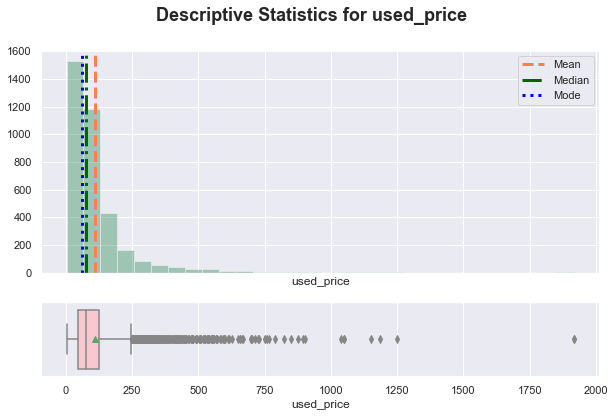

```python
dist_box(phone["used_price"])
```

### Q2 What percentage of the used phone market is dominated by Android devices?

```python
# Grouping by brand name and os (operating system)

brand_counts = phone[["os", "brand_name"]].groupby(["os"]).count()
brand_counts
```

| os | brand_name |
| --- | --- |
| Android | 3246 |
| Others | 202 |
| Windows | 67 |
| iOS | 56 |

```python
# Calculating percentage of used phones dominated by Android os

pct_android = float(
    ((brand_counts.loc["Android"]) / (brand_counts["brand_name"].sum())) * 100
)
print(f"%age of Android phones is {pct_android}%")
```

```
%age of Android phones is 90.89890786894428%
```

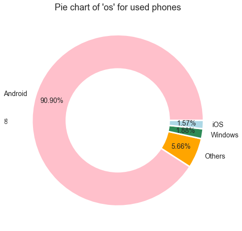

```python
# Creating a donut chart for os

plt.title(
    "Pie chart of 'os' for used phones", fontsize=18
)  # Adding title to the donut chart
phone["os"].value_counts().plot(
    kind="pie",
    colors=["pink", "orange", "seagreen", "lightblue"],
    wedgeprops={"linewidth": 3},
    textprops={"fontsize": 14},
    figsize=(8, 8),
    autopct="%0.2f%%",
    pctdistance=0.8,
)
# Creating the main pie-chart with different parameters
centre_circle = plt.Circle(
    (0, 0), radius=0.6, linewidth=3, facecolor="white"
)  # Creating a smaller center circle
fig = plt.gcf()  # Fetching the current figure
fig.gca().add_artist(centre_circle)
# Adding the center circle to the pie-chart and printing the result
```

### Observations

- As is evident from the above table and graph, **Android devices dominate** the used phone market to the extent of over **90 percent**.
- iOS devices form the least share of this market at 1.6 percent, while windows phones stand close to 2 percent.
- 'Other' operating systems formed the remaining 5.6 percent of the used phone market.

### Q3 How does the amount of RAM vary with the brand?

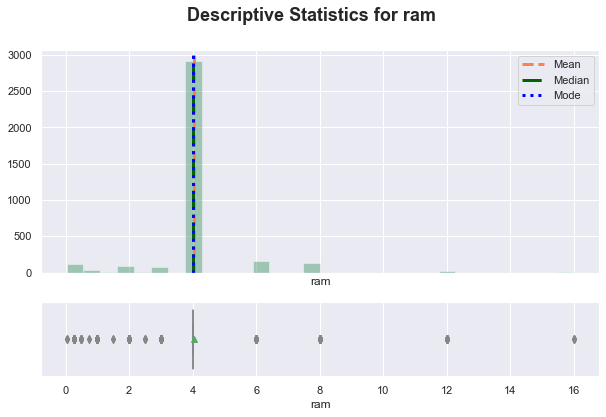

```python
# Using the defined function before (Q1) for plotting a combined histogram and boxplot for RAM.

dist_box(phone["ram"])
```

```python
# Cross-tabulating to get ram by brand_name

ram_br = pd.crosstab(phone["brand_name"], phone["ram"])
ram_br
```

| ram brand_name | 0.03 | 0.25 | 0.50 | 0.75 | 1.00 | 1.50 | 2.00 | 2.50 | 3.00 | 4.00 | 6.00 | 8.00 | 12.00 | 16.00 |
| --- | --- | --- | --- | --- | --- | --- | --- | --- | --- | --- | --- | --- | --- | --- |
| Acer | 0 | 0 | 0 | 0 | 1 | 0 | 1 | 0 | 0 | 49 | 0 | 0 | 0 | 0 |
| Alcatel | 0 | 7 | 3 | 0 | 10 | 0 | 2 | 0 | 1 | 102 | 0 | 0 | 0 | 0 |
| Apple | 0 | 0 | 0 | 0 | 0 | 0 | 1 | 0 | 2 | 54 | 2 | 0 | 0 | 0 |
| Asus | 0 | 0 | 0 | 0 | 0 | 0 | 2 | 0 | 0 | 121 | 1 | 2 | 0 | 0 |
| BlackBerry | 0 | 1 | 0 | 0 | 0 | 0 | 0 | 0 | 0 | 21 | 0 | 0 | 0 | 0 |
| Celkon | 0 | 25 | 0 | 0 | 0 | 0 | 0 | 0 | 0 | 12 | 0 | 0 | 0 | 0 |
| Coolpad | 0 | 0 | 0 | 0 | 0 | 0 | 0 | 0 | 1 | 21 | 0 | 0 | 0 | 0 |
| Gionee | 0 | 1 | 0 | 0 | 0 | 0 | 0 | 0 | 0 | 55 | 0 | 0 | 0 | 0 |
| Google | 0 | 0 | 0 | 0 | 0 | 0 | 0 | 0 | 0 | 11 | 4 | 0 | 0 | 0 |
| HTC | 0 | 0 | 0 | 0 | 0 | 0 | 0 | 0 | 4 | 104 | 2 | 0 | 0 | 0 |
| Honor | 0 | 0 | 0 | 0 | 0 | 0 | 6 | 0 | 10 | 72 | 14 | 16 | 0 | 0 |
| Huawei | 2 | 5 | 0 | 0 | 2 | 0 | 4 | 0 | 2 | 185 | 34 | 26 | 2 | 2 |
| Infinix | 0 | 0 | 0 | 0 | 0 | 0 | 6 | 0 | 2 | 2 | 0 | 0 | 0 | 0 |
| Karbonn | 0 | 5 | 0 | 0 | 0 | 0 | 0 | 0 | 0 | 25 | 0 | 0 | 0 | 0 |
| LG | 0 | 2 | 2 | 0 | 6 | 0 | 6 | 0 | 14 | 170 | 6 | 6 | 0 | 0 |
| Lava | 0 | 4 | 2 | 0 | 0 | 0 | 2 | 0 | 0 | 28 | 0 | 0 | 0 | 0 |
| Lenovo | 0 | 2 | 0 | 0 | 2 | 0 | 8 | 0 | 2 | 152 | 6 | 0 | 0 | 0 |
| Meizu | 0 | 0 | 0 | 0 | 0 | 0 | 2 | 0 | 0 | 48 | 8 | 4 | 0 | 0 |
| Micromax | 0 | 8 | 0 | 0 | 0 | 0 | 0 | 0 | 0 | 112 | 0 | 0 | 0 | 0 |
| Microsoft | 0 | 0 | 0 | 0 | 0 | 0 | 0 | 0 | 0 | 22 | 0 | 0 | 0 | 0 |
| Motorola | 0 | 0 | 0 | 0 | 0 | 0 | 12 | 0 | 2 | 92 | 2 | 0 | 2 | 0 |
| Nokia | 0 | 11 | 2 | 0 | 2 | 0 | 8 | 4 | 4 | 74 | 2 | 2 | 0 | 2 |
| OnePlus | 0 | 0 | 0 | 0 | 0 | 0 | 0 | 0 | 0 | 10 | 2 | 8 | 2 | 0 |
| Oppo | 0 | 0 | 0 | 0 | 2 | 0 | 2 | 0 | 6 | 85 | 6 | 24 | 4 | 0 |
| Others | 1 | 27 | 1 | 0 | 8 | 0 | 9 | 0 | 4 | 448 | 8 | 3 | 0 | 0 |
| Panasonic | 0 | 0 | 0 | 0 | 0 | 0 | 0 | 0 | 0 | 47 | 0 | 0 | 0 | 0 |
| Realme | 0 | 0 | 0 | 0 | 0 | 0 | 4 | 0 | 8 | 17 | 12 | 0 | 0 | 0 |
| Samsung | 0 | 2 | 0 | 2 | 1 | 2 | 6 | 0 | 8 | 320 | 10 | 6 | 7 | 0 |
| Sony | 0 | 0 | 0 | 0 | 0 | 0 | 0 | 0 | 0 | 86 | 1 | 1 | 0 | 0 |
| Spice | 0 | 2 | 0 | 0 | 0 | 0 | 0 | 0 | 0 | 28 | 0 | 0 | 0 | 0 |
| Vivo | 0 | 0 | 1 | 0 | 0 | 0 | 2 | 0 | 2 | 83 | 9 | 20 | 0 | 0 |
| XOLO | 0 | 0 | 0 | 0 | 0 | 0 | 0 | 0 | 0 | 49 | 0 | 0 | 0 | 0 |
| Xiaomi | 0 | 0 | 0 | 0 | 1 | 0 | 4 | 0 | 7 | 89 | 21 | 11 | 1 | 0 |
| ZTE | 0 | 1 | 0 | 0 | 2 | 0 | 3 | 0 | 3 | 124 | 5 | 3 | 0 | 0 |

```python
# Looking at the number of phones in each ram category

ram_br.sum()
```

```
ram
0.03        3
0.25      103
0.50       11
0.75        2
1.00       37
1.50        2
2.00       90
2.50        4
3.00       82
4.00     2918
6.00      155
8.00      132
12.00      18
16.00       4
dtype: int64
```

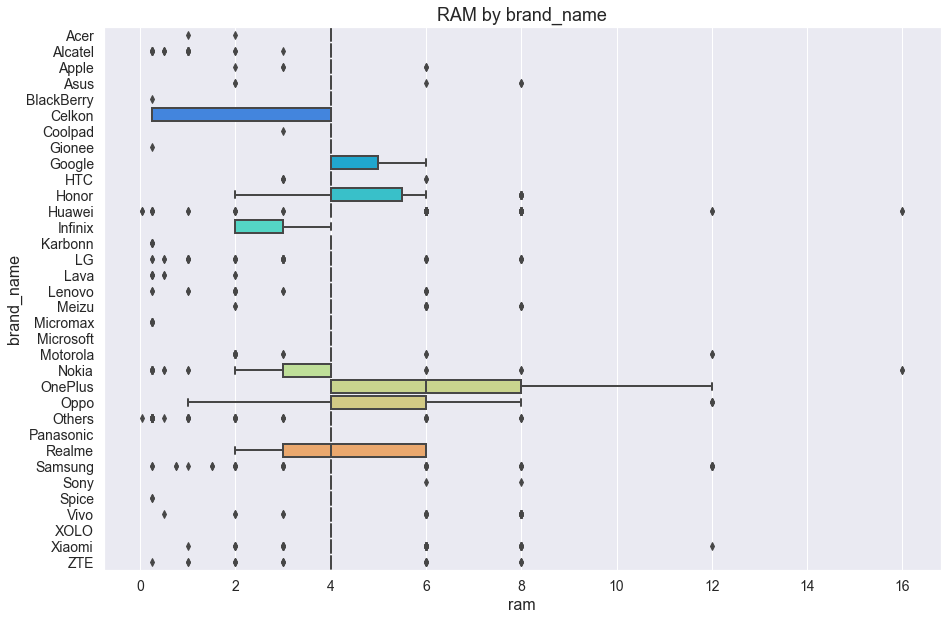

```python
# ram by brand_name

plt.figure(figsize=(15, 10))
plt.title("RAM by brand_name", fontsize=18)  # Setting plot title
plt.xlabel("xlabel", fontsize=16)  # Setting x-axis label font size
plt.ylabel("ylabel", fontsize=16)  # Setting y-axis label font size
plt.xticks(fontsize=14)  # Setting x-axis font size
plt.yticks(fontsize=14)  # Setting y-axis font size
sns.boxplot(
    data=phone, x="ram", y="brand_name", palette="rainbow", linewidth=2
)  # Plotting the boxplot
```

### Observations

- On the whole, 'ram' has a mean of around 4.05GB, which is almost identical to the median and mode value of 4GB. Since, the ram is on the lower side, we are not looking at very superior functioning phones. This can possibly be one of the reasons for these phones ending up in the second-hand/used market.
- The distribution and boxplot shows presence of outliers, both to the left and the right. The maximum ram value for few brands is 16GB, while the minimum for some brands is as low as 0.03GB.
- 82 percent (2918 of 3561) used phones that form a part of the sample have a ram of 4GB.
- **Huawei** exhibits the maximum spread, with phones in almost all categories of ram, lowest(0.03) as well as highest(16) ram.
- With respect to ram by brand_name, only **Huawei** and **Nokia** have used phones with ram of **16GB.**
- Brands with **12GB** ram include **Huawei, Motorola, OnePlus, Oppo, Samsung** and **Xiaomi**.
- **Huawei** followed by **Oppo, Vivo, Honor** and **Xiaomi** have phones in the higher ram category of 6-8 GB.
- **Samsung** along with some other brands has the maximum phones in the 4GB band.
- Few brands do not have any phones with ram < 4GB. These include **Google, Microsoft, OnePlus, Panasonic, Sony, XOLO**.
- On the lower end, **Celkon** along with some **other** brands, has phones with the lowest ram (0.03-0.25 GB)
- Further on, looking at the relationship between ram and price of these used phones might provide interesting insights.

### Q4 How does the weight vary for phones offering large batteries (more than 4500 mAh)?

```python
# Creating a new dataframe with battery > 4500 mAh

wt_bat = phone[["battery", "weight"]]
heavy_bat = wt_bat[wt_bat["battery"] > 4500]
```

```python
# Looking at the statistical summary of the data

heavy_bat.describe().T
```

|  | count | mean | std | min | 25% | 50% | 75% | max |
| --- | --- | --- | --- | --- | --- | --- | --- | --- |
| battery | 346.0 | 5884.102601 | 1327.656254 | 4520.0 | 5000.0 | 5100.0 | 6690.0 | 12000.0 |
| weight | 346.0 | 330.718786 | 160.952677 | 23.0 | 198.0 | 299.0 | 467.0 | 950.0 |

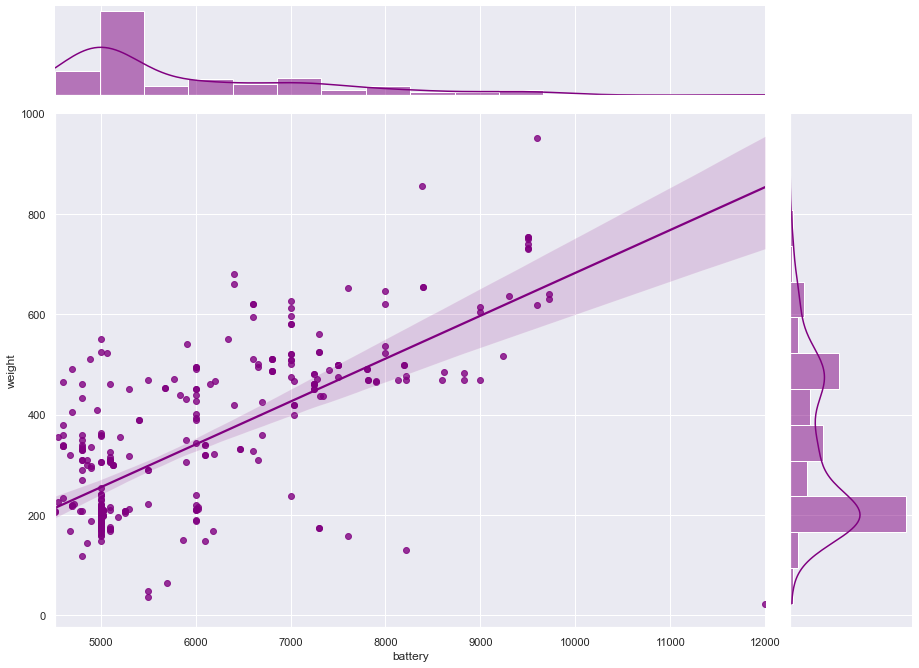

```python
# Joinplot to explore the relationship between battery and weight

sns.jointplot(
    data=heavy_bat, x="battery", y="weight", ci=95, kind="reg", color="purple"
)
plt.gcf().set_size_inches(14, 10)
```

```python
# Compluting correlation between battery and weight

heavy_bat.corr()
```

|  | battery | weight |
| --- | --- | --- |
| battery | 1.000000 | 0.704237 |
| weight | 0.704237 | 1.000000 |

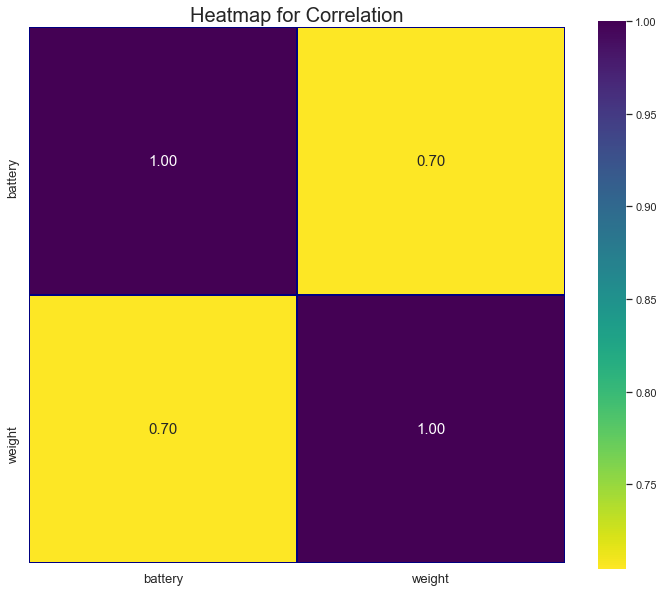

```python
# Creating heatmap for showing above correlation

plt.figure(figsize=(12, 12))
plt.title("Heatmap for Correlation", fontsize=20)  # Setting plot title
plt.xticks(fontsize=13)  # Setting x-axis font size
plt.yticks(fontsize=13)  # Setting y-axis font size
sns.heatmap(
    heavy_bat.corr(),
    square=True,
    linewidths=0.8,
    linecolor="navy",
    cmap="viridis_r",
    fmt=".2f",
    annot=True,
    annot_kws={"size": 15},
    cbar_kws={"shrink": 0.84},
)
```

### Observations

- Out of the total sample, there are **346** used phones with battery > 4500 mAh.
- The mean battery size for these phones is ~5885 mAh, while the mean weight is 330 gms.
- There seem to be outliers on the right side for the variable battery, signifying presence of a phone with very large battery. Similarly, weight too appears to have outliers. These will be explored in detail later.
- It is evident from the graph that battery and weight have a **positive correlation**, i.e., phones with larger battery generally weigh more.
- Pearson's correlation coefficient **(r) = 0.70**, indicating a **high correlation** between battery (>4500 mAh) and weight. However, this too will be explored further, post processing of data.

### Q5 How many phones are available across different brands with a screen size larger than 6 inches?

```python
# Let's convert the existing units of cm for screen size to inches by using a lambda function
# The conversion factor is 1 inch = 2.54 cm

print(phone["screen_size"].head(5))  # Printing screen_size before applying function

phone["screen_size"] = phone["screen_size"].apply(lambda cm: round(cm / 2.54, 2))
phone["screen_size"].head(5)  # Printing screen_size after applying function
```

```
0    23.97
1    28.10
2    24.29
3    26.04
4    15.72
Name: screen_size, dtype: float64
```

```
0     9.44
1    11.06
2     9.56
3    10.25
4     6.19
Name: screen_size, dtype: float64
```

```python
# Creating a new dataframe with phones with screen_size > 6 inches and looking at the first few rows

large_ss = phone[phone["screen_size"] > 6]
large_ss.head()
```

|  | brand_name | os | screen_size | 4g | 5g | main_camera_mp | selfie_camera_mp | int_memory | ram | battery | weight | release_year | days_used | new_price | used_price |
| --- | --- | --- | --- | --- | --- | --- | --- | --- | --- | --- | --- | --- | --- | --- | --- |
| 0 | Honor | Android | 9.44 | 1 | 0 | 13.0 | 5.0 | 64.0 | 3.0 | 3020.0 | 146.0 | 2020 | 127 | 111.62 | 86.96 |
| 1 | Honor | Android | 11.06 | 1 | 1 | 13.0 | 16.0 | 128.0 | 8.0 | 4300.0 | 213.0 | 2020 | 325 | 249.39 | 161.49 |
| 2 | Honor | Android | 9.56 | 1 | 1 | 13.0 | 8.0 | 128.0 | 8.0 | 4200.0 | 213.0 | 2020 | 162 | 359.47 | 268.55 |
| 3 | Honor | Android | 10.25 | 1 | 1 | 13.0 | 8.0 | 64.0 | 6.0 | 7250.0 | 480.0 | 2020 | 345 | 278.93 | 180.23 |
| 4 | Honor | Android | 6.19 | 1 | 0 | 13.0 | 8.0 | 64.0 | 3.0 | 5000.0 | 185.0 | 2020 | 293 | 140.87 | 103.80 |

```python
# Checking the shape of the new dataset to get the total number of phones with screen_size > 6 inches

large_ss.shape
```

```
(1235, 15)
```

```python
# Using the groupby function with .size() to fetch brand-wise number of phones with screen_size > 6 inches

ss_br = large_ss.groupby(by=["brand_name"])["screen_size"].size()
ss_br
```

```
brand_name
Acer           19
Alcatel        28
Apple          24
Asus           44
BlackBerry      2
Celkon          2
Coolpad         3
Gionee          7
Google          4
HTC             8
Honor          87
Huawei        159
Infinix        10
Karbonn         2
LG             68
Lava            2
Lenovo         72
Meizu          25
Micromax       11
Microsoft       1
Motorola       44
Nokia          28
OnePlus        16
Oppo           70
Others        116
Panasonic       2
Realme         40
Samsung       128
Sony           14
Spice           2
Vivo           86
XOLO            4
Xiaomi         85
ZTE            22
Name: screen_size, dtype: int64
```

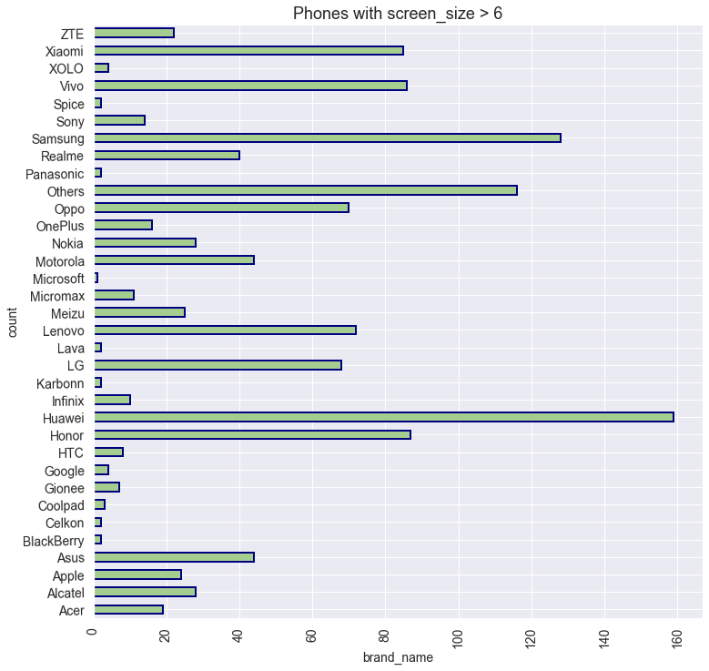

```python
# Creating barplot for phones with screen_size > 6 inches

ss_br.plot(
    kind="barh",
    colormap="crest",
    figsize=(12, 12),
    rot=1,
    linewidth=2,
    edgecolor="navy",
    fontsize=14,
)
plt.title("Phones with screen_size > 6", Fontsize=18)  # Setting plot title
plt.xlabel("brand_name", fontsize=14)  # Setting x-axis label
plt.ylabel("count", fontsize=14)  # Setting y-axis label
plt.xticks(rotation=90)
plt.show()
```

### Observations

- Thus, it can be said that a total of **1235 phones** across different brands have screen sizes larger than 6 inches. This makes up ~**35 percent** (1235/3571 *100) of the total phones in the study.
- **Huawei** with **159** phones has the maximum number of phones with screen sizes greater than 6 inches. This is followed by **Samsung** at **128** and other brands at 116. These phones could be desirable for entertainment purposes as they offer a better viewing experience.
- **Microsoft** has only **1** phone with a large screen_size, while **Blackberry, Celkon, Karbonn, Lava, Panasonic** and **Spice** has **2** phones with screen sizes of upwards of 6 inches.

### Q6 What is the distribution of budget phones offering greater than 8MP selfie cameras across brands?

#### Since the price points of the phones have not been defined, column binning is being carried out to categorize phones into three segments:

- **Low-range/Budget phones**
- **Mid-range phones**
- **High-range phones**
- The new price would form the base for budget phone classification since the customer will buy the phones at new price.
- For binning by distance, the cut() function in pandas will be employed and the interval range for each group will be specified.
- Since, by using binning by distance and calculating the interval range using the maximum and minimum value of the column and using the linspace() function is yielding unsatisfactory intervals, we will resort to binning manually by using the 1st and 3rd quartile as bin breaks.

```python
# Looking at the statistical summary of the new_price column

phone["new_price"].describe()
```

```
count    3571.000000
mean      237.389037
std       197.545581
min         9.130000
25%       120.130000
50%       189.800000
75%       291.935000
max      2560.200000
Name: new_price, dtype: float64
```

```python
# Binning the new_price into 3 categories

phone["price_bin"] = pd.cut(
    phone["new_price"],
    bins=[-np.inf, 120.130, 291.935, np.inf],
    labels=["Low-range/Budget phones", "Mid-range phones", "High-range phones"],
)

# Looking at the value counts of the new price_bin
phone["price_bin"].value_counts(dropna=False)
```

```
Mid-range phones           1784
Low-range/Budget phones     894
High-range phones           893
Name: price_bin, dtype: int64
```

```python
# Dropping the new_price column as it is no longer needed

phone.drop(["new_price"], axis=1, inplace=True)
```

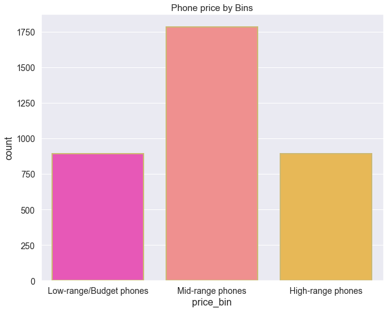

```python
# Creating barplot for phone price by bins

plt.figure(figsize=(10, 8))
sns.countplot(phone["price_bin"], palette="spring", linewidth=2, edgecolor="y")
plt.title("Phone price by Bins", Fontsize=15)
plt.xticks(fontsize=14)  # Setting x-axis font size
plt.yticks(fontsize=14)  # Setting y-axis font size
plt.xlabel("price_bin", fontsize=16)  # Setting x-axis label font size
plt.ylabel("count", fontsize=16)  # Setting y-axis label font size
```

```python
# Creating a new dataframe with phones offering greater than 8MP selfie cameras and looking at the first few rows

large_sc = phone[phone["selfie_camera_mp"] > 8]
large_sc.head()
```

|  | brand_name | os | screen_size | 4g | 5g | main_camera_mp | selfie_camera_mp | int_memory | ram | battery | weight | release_year | days_used | used_price | price_bin |
| --- | --- | --- | --- | --- | --- | --- | --- | --- | --- | --- | --- | --- | --- | --- | --- |
| 1 | Honor | Android | 11.06 | 1 | 1 | 13.0 | 16.0 | 128.0 | 8.0 | 4300.0 | 213.0 | 2020 | 325 | 161.49 | Mid-range phones |
| 8 | Honor | Android | 6.19 | 1 | 0 | 13.0 | 16.0 | 128.0 | 6.0 | 4000.0 | 165.0 | 2020 | 161 | 150.88 | Mid-range phones |
| 12 | Honor | Android | 9.56 | 1 | 1 | 13.0 | 16.0 | 128.0 | 8.0 | 4100.0 | 206.0 | 2019 | 537 | 249.81 | High-range phones |
| 13 | Honor | Others | 3.44 | 0 | 0 | 13.0 | 16.0 | 4.0 | 4.0 | 455.0 | 41.0 | 2019 | 432 | 89.77 | Mid-range phones |
| 14 | Honor | Android | 6.19 | 1 | 0 | 13.0 | 16.0 | 64.0 | 4.0 | 4000.0 | 171.5 | 2019 | 336 | 144.87 | Mid-range phones |

```python
large_sc.shape
```

```
(666, 15)
```

```python
# Using the above created dataframe to create another dataframe with only low-range/budget phones

new_df = large_sc[(large_sc["price_bin"] == "Low-range/Budget phones")]
new_df
```

|  | brand_name | os | screen_size | 4g | 5g | main_camera_mp | selfie_camera_mp | int_memory | ram | battery | weight | release_year | days_used | used_price | price_bin |
| --- | --- | --- | --- | --- | --- | --- | --- | --- | --- | --- | --- | --- | --- | --- | --- |
| 63 | Infinix | Android | 6.37 | 1 | 0 | NaN | 16.0 | 32.0 | 3.0 | 4000.0 | 178.0 | 2019 | 316 | 64.51 | Low-range/Budget phones |
| 202 | Xiaomi | Others | 3.44 | 0 | 0 | NaN | 16.0 | 64.0 | 6.0 | 420.0 | 208.0 | 2020 | 153 | 75.34 | Low-range/Budget phones |
| 288 | Infinix | Android | 6.37 | 1 | 0 | NaN | 16.0 | 32.0 | 3.0 | 4000.0 | 178.0 | 2019 | 356 | 63.94 | Low-range/Budget phones |
| 1859 | Meizu | Android | 7.81 | 1 | 0 | 13.0 | 13.0 | 32.0 | 4.0 | 3000.0 | 150.0 | 2018 | 635 | 44.06 | Low-range/Budget phones |
| 3196 | ZTE | Android | 5.31 | 1 | 0 | 13.0 | 16.0 | 64.0 | 4.0 | 3000.0 | 164.0 | 2017 | 879 | 35.74 | Low-range/Budget phones |
| 3424 | Xiaomi | Android | 6.19 | 1 | 0 | 12.0 | 13.0 | 32.0 | 3.0 | 4000.0 | 200.0 | 2019 | 444 | 59.33 | Low-range/Budget phones |

```python
new_df.shape
```

```
(6, 15)
```

```python
# Cross-tabulating to get budget phones with selfie camera > 8MP

sc_b = pd.crosstab(new_df["brand_name"], new_df["selfie_camera_mp"])
sc_b
```

| selfie_camera_mp brand_name | 13.0 | 16.0 |
| --- | --- | --- |
| Infinix | 0 | 2 |
| Meizu | 1 | 0 |
| Xiaomi | 1 | 1 |
| ZTE | 0 | 1 |

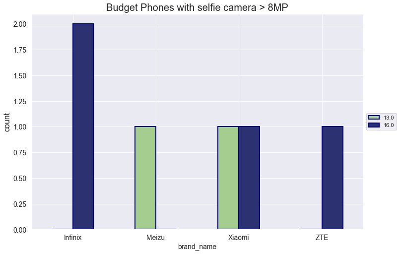

```python
# Creating barplot for budget phones with selfie camera > 8MP

sc_b.plot(
    kind="bar",
    colormap="crest",
    figsize=(12, 8),
    rot=1,
    linewidth=2,
    edgecolor="navy",
    fontsize=14,
)
plt.title("Budget Phones with selfie camera > 8MP", Fontsize=20)  # Setting plot title
plt.xlabel("brand_name", fontsize=14)  # Setting y-axis label font size
plt.ylabel("count", fontsize=16)  # Setting y-axis label font size
plt.xticks(fontsize=14)  # Setting x-axis font size
plt.yticks(fontsize=14)  # Setting y-axis font size
plt.legend(loc="center left", bbox_to_anchor=(1, 0.5))
plt.show()
```

### Observations

- Therefore, it can be discerned that out of all the categories of phones, **6** phones out of 894 phones from the budget category, i.e., **Low-range/Budget phones have selfie camera > 8MP**.
- Alternatively, it can also be said that out of a total of 666 phones that have selfie camera > 8MP, only 6 belong to the Low-range/Budget phone category.
- The four brands that make up these 6 budget phones include:
  - **Infinix** with **2 phones** with selfie camera of **16MP**,
  - **Meizu** with **1 phone** with selfie camera of **13MP**,
  - **Xiaomi** with **1 phone** with selfie camera of **13MP** and **1 phone** with selfie camera of **16MP**,
  - **ZTE** with **1 phone** with selfie camera of **16MP**.

### Q7 Which attributes are highly correlated with the used phone price?

- For the present categorical variables - 'brand_name' and 'os', correlation with used phone price cannot be computed, as correlation only takes in numerical variables.
- However, bivariate analysis can be done to guage the relationship between these variables.
- In case of continuous/numerical variables, relationship between used phone price and every other variable can be observed by calculating the correlation coefficient (r) and thereafter, depicting this relationship via a heatmap.

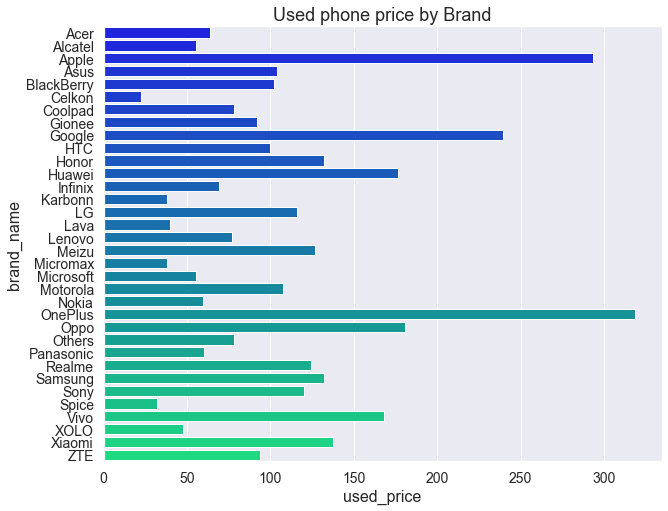

```python
# Creating barplot for used_price by brand_name (Categorical variable, therefore, won't go into correlation)

plt.figure(figsize=(10, 8))
plt.xlabel("xlabel", fontsize=16)  # Setting x-axis label font size
plt.ylabel("ylabel", fontsize=16)  # Setting y-axis label font size
plt.xticks(fontsize=14)  # Setting x-axis font size
plt.yticks(fontsize=14)  # Setting y-axis font size
sns.barplot(
    data=phone, x="used_price", y="brand_name", orient="h", ci=None, palette="winter"
)
plt.title("Used phone price by Brand", fontsize=18)  # Setting plot title
```

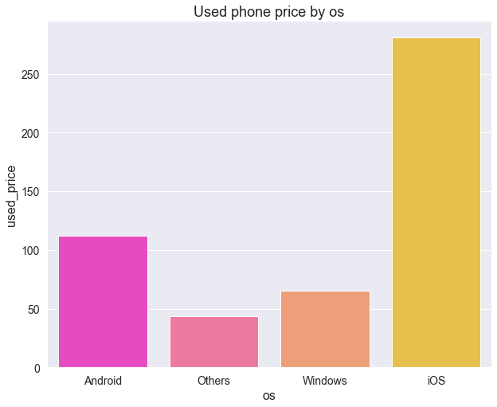

```python
# Creating barplot for used_price by os     (Another Categorical variable that won't go into correlation)

plt.figure(figsize=(10, 8))
plt.title("Used phone price by os", fontsize=18)  # Setting plot title
plt.xlabel("xlabel", fontsize=16)  # Setting x-axis label font size
plt.ylabel("ylabel", fontsize=16)  # Setting y-axis label font size
plt.xticks(fontsize=14)  # Setting x-axis font size
plt.yticks(fontsize=14)  # Setting y-axis font size
sns.barplot(data=phone, x="os", y="used_price", ci=None, palette="spring")
```

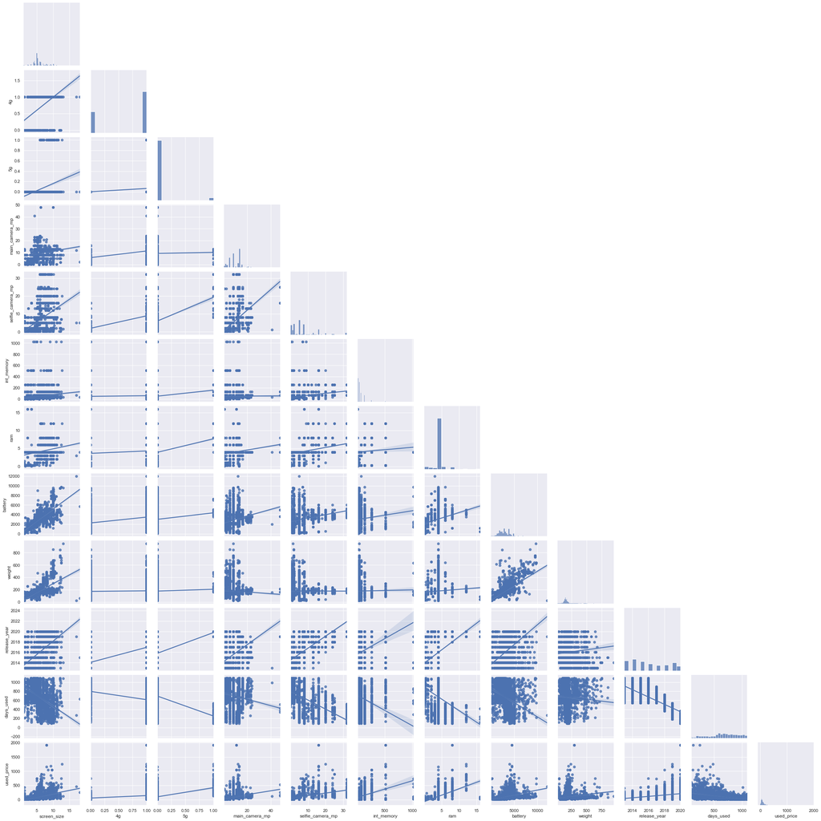

```python
# In order to get two-dimensional distributions in case of multiple datasets, a 'pairplot' is being used, along with a regression line fitting through the data.

sns.pairplot(data=phone, kind='reg', corner=True);     # Creating a pairplot for all numerical variables
```

```python
# Calculating Pearson's correlation for used_price with other continuous variables

numeric_columns = phone.select_dtypes(include=np.number).columns.tolist()
numeric_colums1 = numeric_columns.remove(
    "release_year"
)  # dropping year column as it is temporal variable

corr = phone[numeric_columns].corr()
corr
```

|  | screen_size | 4g | 5g | main_camera_mp | selfie_camera_mp | int_memory | ram | battery | weight | days_used | used_price |
| --- | --- | --- | --- | --- | --- | --- | --- | --- | --- | --- | --- |
| screen_size | 1.000000 | 0.337935 | 0.276656 | 0.189422 | 0.370358 | 0.143741 | 0.283378 | 0.741818 | 0.634770 | -0.397237 | 0.385965 |
| 4g | 0.337935 | 1.000000 | 0.151133 | 0.550904 | 0.479524 | 0.066154 | 0.227182 | 0.421407 | 0.048541 | -0.349507 | 0.337473 |
| 5g | 0.276656 | 0.151133 | 1.000000 | 0.027629 | 0.388490 | 0.257731 | 0.548375 | 0.201707 | 0.066479 | -0.357415 | 0.532846 |
| main_camera_mp | 0.189422 | 0.550904 | 0.027629 | 1.000000 | 0.423704 | 0.004032 | 0.206895 | 0.239659 | -0.073371 | -0.142915 | 0.281065 |
| selfie_camera_mp | 0.370358 | 0.479524 | 0.388490 | 0.423704 | 1.000000 | 0.283188 | 0.445200 | 0.344864 | -0.005384 | -0.556027 | 0.497530 |
| int_memory | 0.143741 | 0.066154 | 0.257731 | 0.004032 | 0.283188 | 1.000000 | 0.079572 | 0.113488 | 0.017879 | -0.228636 | 0.404913 |
| ram | 0.283378 | 0.227182 | 0.548375 | 0.206895 | 0.445200 | 0.079572 | 1.000000 | 0.234465 | 0.069766 | -0.286884 | 0.522659 |
| battery | 0.741818 | 0.421407 | 0.201707 | 0.239659 | 0.344864 | 0.113488 | 0.234465 | 1.000000 | 0.704468 | -0.351055 | 0.363767 |
| weight | 0.634770 | 0.048541 | 0.066479 | -0.073371 | -0.005384 | 0.017879 | 0.069766 | 0.704468 | 1.000000 | -0.059272 | 0.170654 |
| days_used | -0.397237 | -0.349507 | -0.357415 | -0.142915 | -0.556027 | -0.228636 | -0.286884 | -0.351055 | -0.059272 | 1.000000 | -0.470760 |
| used_price | 0.385965 | 0.337473 | 0.532846 | 0.281065 | 0.497530 | 0.404913 | 0.522659 | 0.363767 | 0.170654 | -0.470760 | 1.000000 |

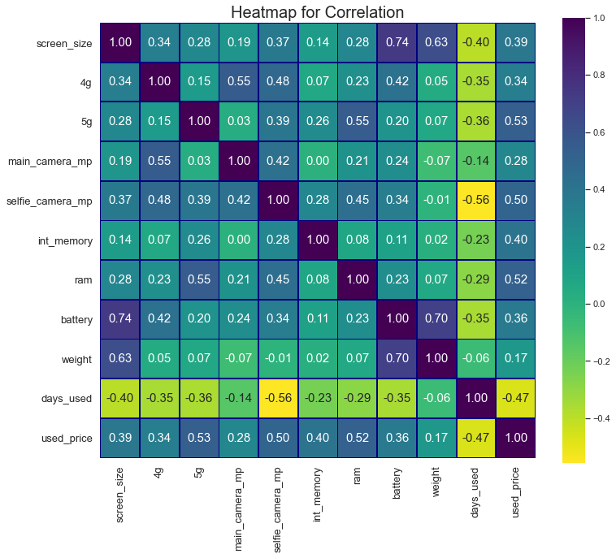

```python
# Creating heatmap for showing above correlations

plt.figure(figsize=(12, 12))
plt.title("Heatmap for Correlation", fontsize=20)  # Setting plot title
plt.xticks(fontsize=13)  # Setting x-axis font size
plt.yticks(fontsize=13)  # Setting y-axis font size
sns.heatmap(
    phone[numeric_columns].corr(),
    square=True,
    linewidths=0.8,
    linecolor="navy",
    cmap="viridis_r",
    fmt=".2f",
    annot=True,
    annot_kws={"size": 15},
    cbar_kws={"shrink": 0.84},
)
```

### Observations

- Correlation only helps us understand the relationship between numerical variables.
- used_price has a positive relationship with almost all variables in the study, expect a negative correlation of **-0.47** with **days_used**. This makes complete sense as greater the number of days a phone is used for, lower should be its price.
- **ram** and **selfie_camera_mp** also have a moderate correlation of **0.52** and **0.50** respectively, with used_price.

### Although the above questions have been answered, few of these will need to be revisited after data preprocessing.

# II. Data Preprocessing

## 1. Duplicate Value Check

```python
# Checking for duplicate values
# The result of .duplicate() is a boolean series and adding .sum()
# returns 1 for True (presence of duplicates) and 0 for False (no duplicates)

phone.duplicated().sum()
```

```
0
```

#### Observations

- These seem to be no duplicate values in the data.

## 2. Missing Value Check & Treatment

```python
# checking for missing values again

phone.isnull().sum()
```

```
brand_name            0
os                    0
screen_size           0
4g                    0
5g                    0
main_camera_mp      180
selfie_camera_mp      2
int_memory           10
ram                  10
battery               6
weight                7
release_year          0
days_used             0
used_price            0
price_bin             0
dtype: int64
```

#### Observations

- There are no missing values in the dependent variable, used_price.
- The maximum missing values of 180 are in the 'main_camera_mp' variable, while 'int_memory' and 'ram' have 10 missing values each.

```python
# Summing over axis to find the row-wise missing values

phone.isnull().sum(axis=1).value_counts()
```

```
0    3368
1     193
2       8
3       2
dtype: int64
```

#### Observations

- Vast majority of rows (3368) have no missing values.
- 193 rows have just 1 missing value.
- These missing values in the numeric predictor variables would be treated via **imputation with median**

```python
# Defining a lambda function for filling in the missing values with the median value

medianFiller = lambda x: x.fillna(x.median())
numeric_columns = phone.select_dtypes(include=np.number).columns.tolist()
phone[numeric_columns] = phone[numeric_columns].apply(medianFiller, axis=0)
```

```python
# Checking for the number of missing values now

phone.isnull().sum()
```

```
brand_name          0
os                  0
screen_size         0
4g                  0
5g                  0
main_camera_mp      0
selfie_camera_mp    0
int_memory          0
ram                 0
battery             0
weight              0
release_year        0
days_used           0
used_price          0
price_bin           0
dtype: int64
```

#### Observations

- Therefore, all the missing value have been treated.
- Some of the treated variables have been used in the EDA above. However, since the dataset has had very few missing values, there has been no significant impact of this treatment on Q3, Q4, Q6 and Q7.

## 3. Feature Engineering

```python
# Converting caterogical columns into categorical types

phone["4g"] = phone["4g"].astype("category")
phone["5g"] = phone["5g"].astype("category")
```

#### Since the dataset contains 34 manufacturing brands of phones, we can try binning this column on the basis of price bands.

- Three bins, namely, Low-range/Budget phones, Mid-range phones and High-range phones have already been created earlier (Q6) based on new_price.
- This binning can be taken further to categorize brand_name into the following 3 segments:
  - **Low-Cost Brand**
  - **Mid-Range Brand**
  - **High-End Brand**

```python
# Cross-tabulating by brand_name and price_bin to get the low-range, mid-range and high-range phones for each brand

br_pb = pd.crosstab(phone["brand_name"], phone["price_bin"])
br_pb
```

| price_bin brand_name | Low-range/Budget phones | Mid-range phones | High-range phones |
| --- | --- | --- | --- |
| Acer | 15 | 32 | 4 |
| Alcatel | 60 | 59 | 6 |
| Apple | 0 | 4 | 55 |
| Asus | 18 | 76 | 32 |
| BlackBerry | 5 | 9 | 8 |
| Celkon | 34 | 3 | 0 |
| Coolpad | 6 | 12 | 4 |
| Gionee | 13 | 26 | 17 |
| Google | 0 | 3 | 12 |
| HTC | 5 | 73 | 32 |
| Honor | 17 | 72 | 29 |
| Huawei | 35 | 140 | 89 |
| Infinix | 8 | 2 | 0 |
| Karbonn | 18 | 12 | 0 |
| LG | 44 | 119 | 49 |
| Lava | 23 | 13 | 0 |
| Lenovo | 40 | 105 | 27 |
| Meizu | 5 | 34 | 23 |
| Micromax | 78 | 40 | 2 |
| Microsoft | 10 | 9 | 3 |
| Motorola | 20 | 73 | 17 |
| Nokia | 76 | 30 | 15 |
| OnePlus | 0 | 2 | 20 |
| Oppo | 8 | 59 | 62 |
| Others | 172 | 247 | 90 |
| Panasonic | 14 | 30 | 3 |
| Realme | 11 | 24 | 6 |
| Samsung | 54 | 170 | 140 |
| Sony | 3 | 56 | 29 |
| Spice | 21 | 9 | 0 |
| Vivo | 9 | 51 | 57 |
| XOLO | 18 | 31 | 0 |
| Xiaomi | 18 | 83 | 33 |
| ZTE | 36 | 76 | 29 |

## 4. Outlier Detection and Treatment

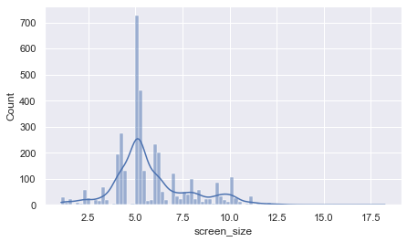

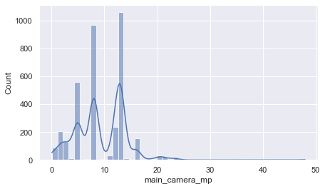

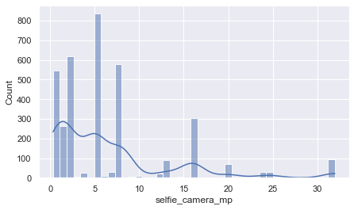

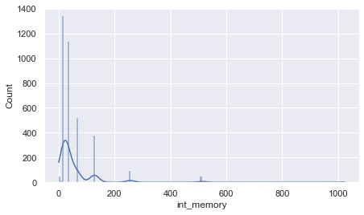

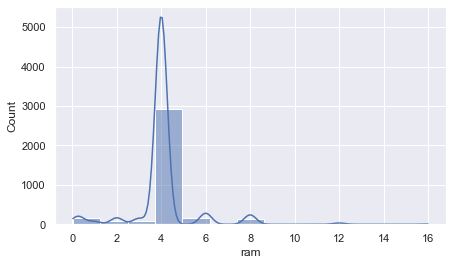

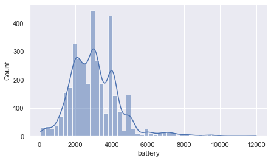

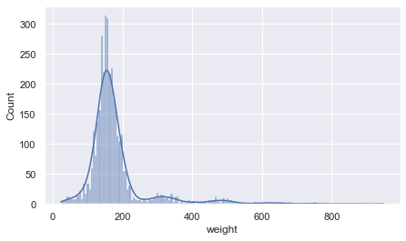

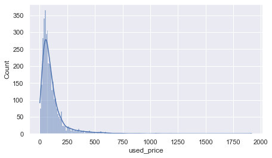

```python
# let's plot all the columns to look at their distributions

for i in phone.columns[phone.dtypes == "float"]:
    plt.figure(figsize=(7, 4))
    sns.histplot(data=phone, x=i, kde=True)
    plt.show()
```

### Outlier Detection

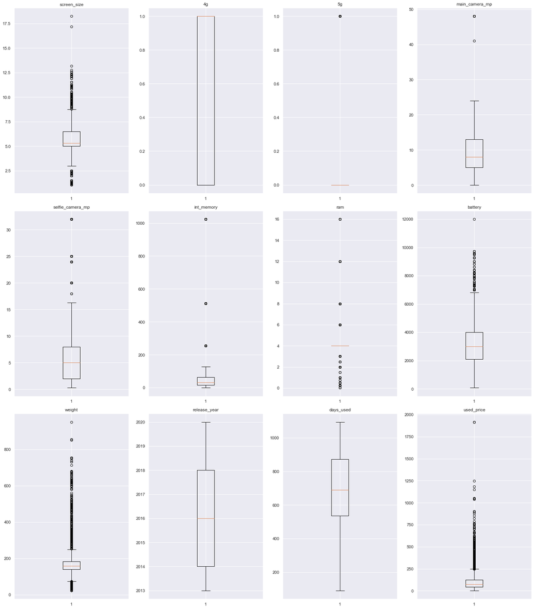

```python
# Let's plot the boxplots of all columns to check for outliers

plt.figure(figsize=(20, 30))

for i, variable in enumerate(numeric_columns):
    plt.subplot(4, 4, i + 1)
    plt.boxplot(phone[variable], whis=1.5)
    plt.tight_layout()
    plt.title(variable)

plt.show()
```

#### Observations

- There are lower outliers in screen_size, ram and weight.
- There are no outliers in release_year and days_used.
- All other numerical columns have upper outliers.
- These outliers as to be treated as these might adversely affect the predictive power of the subsequent linear model.

```python
phone.info()
```

```
<class 'pandas.core.frame.DataFrame'>
RangeIndex: 3571 entries, 0 to 3570
Data columns (total 15 columns):
 #   Column            Non-Null Count  Dtype
---  ------            --------------  -----
 0   brand_name        3571 non-null   category
 1   os                3571 non-null   category
 2   screen_size       3571 non-null   float64
 3   4g                3571 non-null   category
 4   5g                3571 non-null   category
 5   main_camera_mp    3571 non-null   float64
 6   selfie_camera_mp  3571 non-null   float64
 7   int_memory        3571 non-null   float64
 8   ram               3571 non-null   float64
 9   battery           3571 non-null   float64
 10  weight            3571 non-null   float64
 11  release_year      3571 non-null   int64
 12  days_used         3571 non-null   int64
 13  used_price        3571 non-null   float64
 14  price_bin         3571 non-null   category
dtypes: category(5), float64(8), int64(2)
memory usage: 298.4 KB
```

### Outlier Treatment

- **Quantile-based Flooring and Capping** is being applied for treating the above outliers for continuous variables.
- Since, the variables main_camera_mp, selfie_camera_mp, int_memory and ram have discrete values, we won't do outlier treatment for these.

```python
# Defining a function for treating outliers


def treat_outliers(df, col):
    """
    treats outliers in a variable
    col: str, name of the numerical variable
    df: dataframe
    col: name of the column
    """
    Q1 = df[col].quantile(0.25)  # 25th quantile
    Q3 = df[col].quantile(0.75)  # 75th quantile
    IQR = Q3 - Q1
    Lower_Whisker = Q1 - 1.5 * IQR
    Upper_Whisker = Q3 + 1.5 * IQR

    # all the values smaller than Lower_Whisker will be assigned the value of Lower_Whisker
    # all the values greater than Upper_Whisker will be assigned the value of Upper_Whisker
    df[col] = np.clip(df[col], Lower_Whisker, Upper_Whisker)

    return df


def treat_outliers_all(df, col_list):
    """
    treat outlier in all numerical variables
    col_list: list of numerical variables
    df: data frame
    """
    for c in col_list:
        df = treat_outliers(df, c)

    return df
```

```python
# Treating the outliers

col_list = ["screen_size", "battery", "weight", "used_price"]
phone = treat_outliers_all(phone, col_list)
```

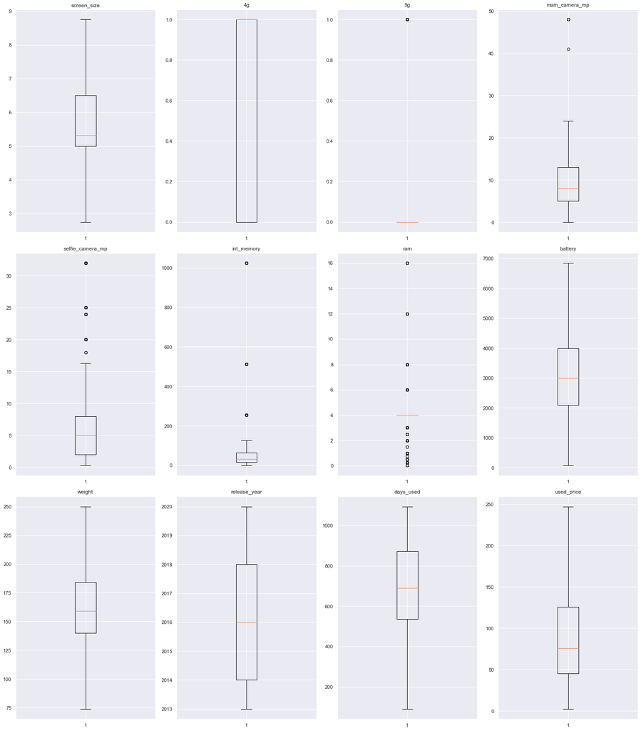

```python
# Let's look at the boxplots to see if the outliers have been treated or not

plt.figure(figsize=(20, 30))

for i, variable in enumerate(numeric_columns):
    plt.subplot(4, 4, i + 1)
    plt.boxplot(phone[variable], whis=1.5)
    plt.tight_layout()
    plt.title(variable)

plt.show()
```

So, ouliers in the continuous variables have been treated.

## 5. Data preparation for modeling

- One-hot encoding would be done post EDA so as to enable visualization with restricted number of columns.

# III. EDA (Contd.)

Since some variables have been treated during data preprocessing, let's revisit the key questions to check if the results have changed.

- There has been no change in the results to Q2, Q3, Q5 and Q6. The rest of the questions are discussed below:

### Q1 What does the distribution of used phone prices look like?

```python
phone["used_price"].describe()
```

```
count    3571.000000
mean       95.528957
std        66.145611
min         2.510000
25%        45.205000
50%        75.530000
75%       126.000000
max       247.192500
Name: used_price, dtype: float64
```

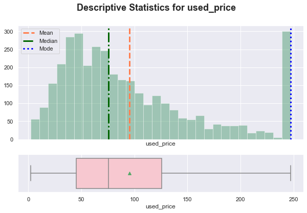

```python
dist_box(phone["used_price"])
```

#### Observations

- As is visible from the boxplot, outliers for used_price have been treated.
- Although the distribution is still a bit skewed due to outliers, it is still closer to the normal distribution than the original distribution.
- Now, the used_price from around 2 euros to 247 euros, with the average price being around 95 euros, which was earlier 110 euros. The extreme outliers on the right (earlier 1900 euros) have been corrected.
- The median used_price is around 75 euros, indicating 50 percent of used phones are priced less than 75 euros and 50 percent priced more than 75 euros. This has remained unchanged after data treatment.
- The third quartile (75 percent) is 126, signifying 25 percent of used phones are priced more than 126 euros, while the first quartile (25 percent) is 45, meaning 25 percent of used phones are priced less than 45 euros.
- Since the above distribution is still skewed, it might behave better on the log scale. This would form a part of data preprocessing(contd.) to be taken up further.

### Q4 How does the weight vary for phones offering large batteries (more than 4500 mAh)?

```python
# Creating a new dataframe with battery > 4500 mAh

wt_bat = phone[["battery", "weight"]]
heavy_bat = wt_bat[wt_bat["battery"] > 4500]
```

```python
heavy_bat.describe().T
```

|  | count | mean | std | min | 25% | 50% | 75% | max |
| --- | --- | --- | --- | --- | --- | --- | --- | --- |
| battery | 346.0 | 5626.91185 | 829.486056 | 4520.0 | 5000.0 | 5100.0 | 6690.0 | 6850.0 |
| weight | 346.0 | 222.89104 | 34.203931 | 74.0 | 198.0 | 250.0 | 250.0 | 250.0 |

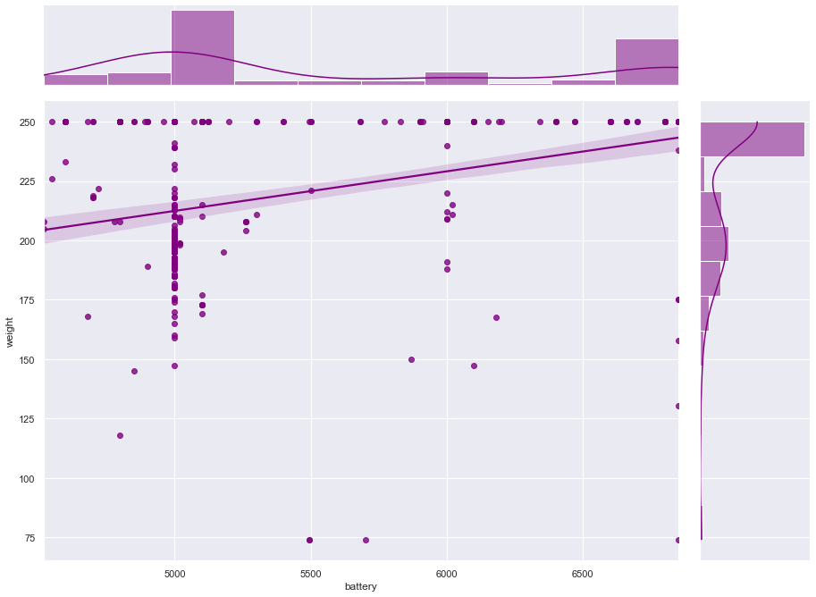

```python
# Joinplot to explore the relationship between battery and weight

sns.jointplot(
    data=heavy_bat, x="battery", y="weight", ci=95, kind="reg", color="purple"
)
plt.gcf().set_size_inches(14, 10)
```

```python
# Compluting correlation between battery and weight

heavy_bat.corr()
```

|  | battery | weight |
| --- | --- | --- |
| battery | 1.000000 | 0.404495 |
| weight | 0.404495 | 1.000000 |

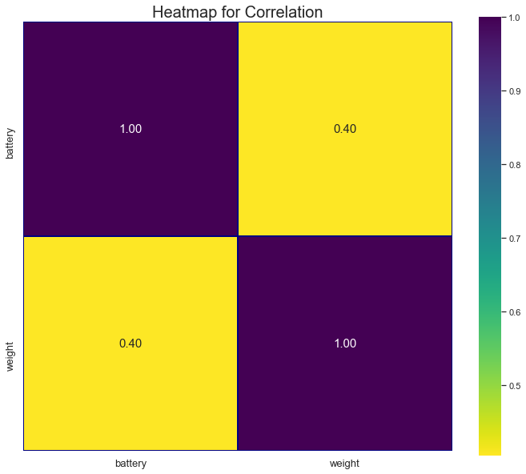

```python
# Creating heatmap for showing above correlation

plt.figure(figsize=(12, 12))
plt.title("Heatmap for Correlation", fontsize=20)  # Setting plot title
plt.xticks(fontsize=13)  # Setting x-axis font size
plt.yticks(fontsize=13)  # Setting y-axis font size
sns.heatmap(
    heavy_bat.corr(),
    square=True,
    linewidths=0.8,
    linecolor="navy",
    cmap="viridis_r",
    fmt=".2f",
    annot=True,
    annot_kws={"size": 15},
    cbar_kws={"shrink": 0.84},
)
```

#### Observations

- Out of the total sample, there are 346 used phones with battery > 4500 mAh.
- After treatment for outliers, both the mean battery size for these phones and the mean weight have come down to ~5627 mAh and 223 gms respectively.
- There is still a **positive correlation** between battery and weight, however it has come down to **0.40** from 0.70. this might be on account of removal of extreme high values during outlier treatment.
- This might have corrected the problem of multicollinearity between these two variables. However, this is only for phones with battery > 4500 mAh and, therefore, this relationship will have to be investigated further while testing the assumptions of linear regression.

### Q7 Which attributes are highly correlated with the used phone price?

```python
# Calculating Pearson's correlation for used_price with other continuous variables

numeric_columns = phone.select_dtypes(include=np.number).columns.tolist()
numeric_columns.remove(
    "release_year"
)  # dropping year column as it is temporal variable

corr = phone[numeric_columns].corr()
corr
```

|  | screen_size | main_camera_mp | selfie_camera_mp | int_memory | ram | battery | weight | days_used | used_price |
| --- | --- | --- | --- | --- | --- | --- | --- | --- | --- |
| screen_size | 1.000000 | 0.188430 | 0.420509 | 0.144494 | 0.292628 | 0.754324 | 0.716022 | -0.436399 | 0.508274 |
| main_camera_mp | 0.188430 | 1.000000 | 0.369802 | -0.003483 | 0.167153 | 0.235756 | 0.060954 | -0.108495 | 0.397673 |
| selfie_camera_mp | 0.420509 | 0.369802 | 1.000000 | 0.283466 | 0.444957 | 0.377111 | 0.187913 | -0.555775 | 0.623243 |
| int_memory | 0.144494 | -0.003483 | 0.283466 | 1.000000 | 0.079594 | 0.115716 | 0.079040 | -0.228819 | 0.302984 |
| ram | 0.292628 | 0.167153 | 0.444957 | 0.079594 | 1.000000 | 0.251833 | 0.190854 | -0.286664 | 0.488588 |
| battery | 0.754324 | 0.235756 | 0.377111 | 0.115716 | 0.251833 | 1.000000 | 0.753402 | -0.376321 | 0.485956 |
| weight | 0.716022 | 0.060954 | 0.187913 | 0.079040 | 0.190854 | 0.753402 | 1.000000 | -0.216427 | 0.358080 |
| days_used | -0.436399 | -0.108495 | -0.555775 | -0.228819 | -0.286664 | -0.376321 | -0.216427 | 1.000000 | -0.553117 |
| used_price | 0.508274 | 0.397673 | 0.623243 | 0.302984 | 0.488588 | 0.485956 | 0.358080 | -0.553117 | 1.000000 |

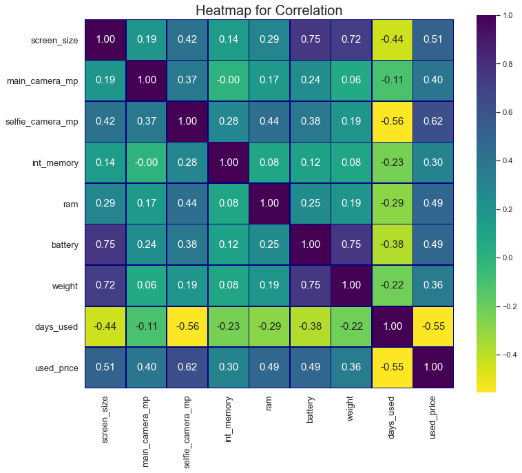

```python
# Creating heatmap for showing above correlations

plt.figure(figsize=(12, 12))
plt.title("Heatmap for Correlation", fontsize=20)  # Setting plot title
plt.xticks(fontsize=13)  # Setting x-axis font size
plt.yticks(fontsize=13)  # Setting y-axis font size
sns.heatmap(
    phone[numeric_columns].corr(),
    square=True,
    linewidths=0.8,
    linecolor="navy",
    cmap="viridis_r",
    fmt=".2f",
    annot=True,
    annot_kws={"size": 15},
    cbar_kws={"shrink": 0.84},
)
```

#### Observations

- After the first rounf of data preprocessing, there have been some changes in the correlations between the numerical variables.
- The negative correlation of the target variable, **used_price** with **days_used** has gone up to **-0.55** from -0.47.
- The positive correlation of used_price with **selfie_camera_mp** has increased from 0.50 to **0.62**, indicating that a higher selfie_camera_mp translates into a higher used_price and vice-versa.
- The moderate correlation of used_price with ram has gone down to 0.49 from 0.52, while screen_size has a correlation of 0.51 with used_price.
- int_memory and weight have the lowest correlation at 0.30 and 0.36 respectively with the target variable, signifying that used_price is not dictated by these two predictors to a great extent.

### Let's look at some relationships with the temporal variable *release_year* and binned variable *price_bin*

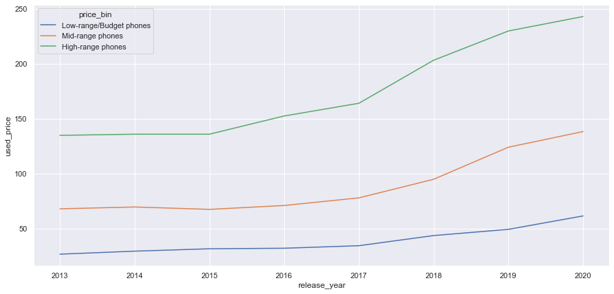

```python
# average used_price according to release_year of the phone

plt.figure(figsize=(15, 7))
sns.lineplot(
    data=phone, x="release_year", y="used_price", hue="price_bin", ci=None, color="r"
)
```

- Thus, average price of used phones tends to increase with an increase in the release year for all three price categories.
- It makes complete sense because a newer (latest release_year) phone model would be priced higher that an older phone model.
- However, the graph for low-range/budget used phones has a very gradual slope, indicating that there is less variation in the price for this category as compared to mid-range and high-range phones.

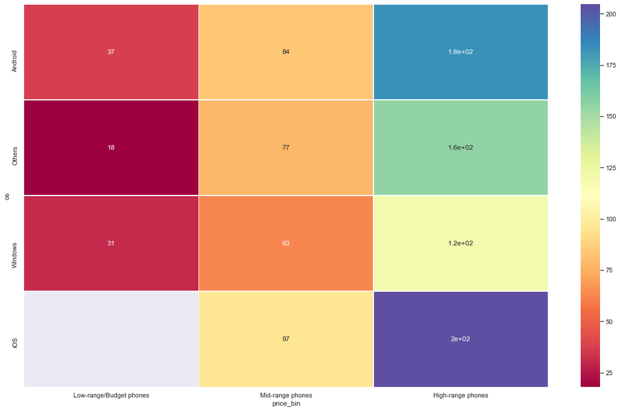

```python
# Median used_price by os and price_bin

up_pb = phone.pivot_table(
    index="os", columns="price_bin", values="used_price", aggfunc=np.mean
)

# To draw a heatmap
f, ax = plt.subplots(figsize=(20, 12))
sns.heatmap(up_pb, cmap="Spectral", linewidths=0.5, annot=True, ax=ax)
plt.show()
```

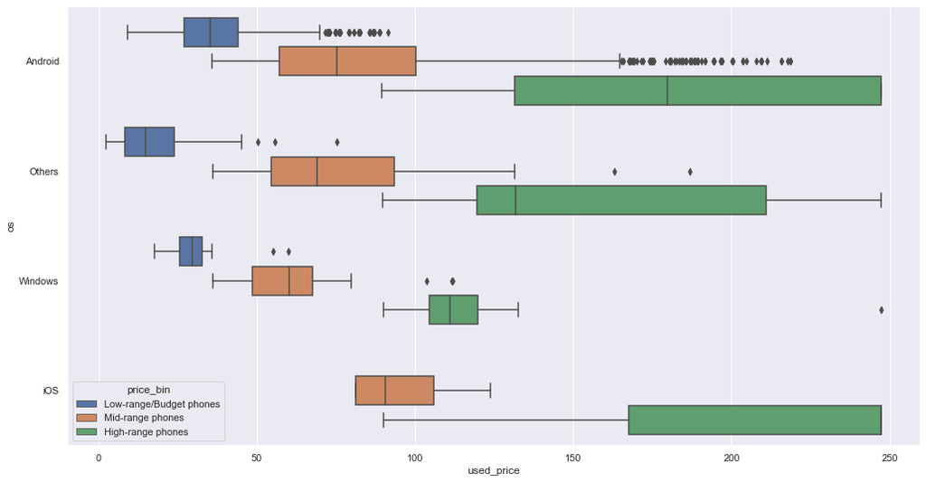

```python
# Creating boxplot used_price by os and price_bin

plt.figure(figsize=(17, 9))
sns.boxplot(y="os", x="used_price", data=phone, hue="price_bin")
plt.show()
```

#### Observations

From the above heatmap and boxplot, it can be concluded that:

- There are no low-range/budget phone that run on iOS.
- The most expensive/high-range phones belong to iOS, followed by android.
- Even the most expensive mid-range phones run on iOS.
- The least expensive high-range and mid-range phones run on windows.
- Apart from these three operating systems (os), there are other os on which the least expensive low-range/budget phones run.

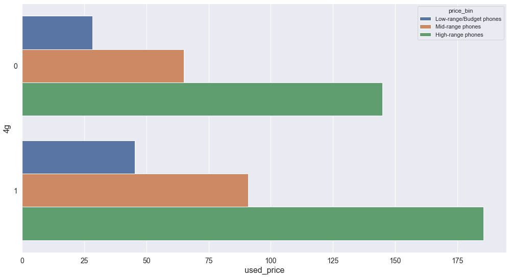

```python
# used_price by 4G availablility and price_bin

plt.figure(figsize=(17, 9))
sns.barplot(y="4g", x="used_price", data=phone, hue="price_bin", ci=None)
plt.xlabel("used_price", fontsize=16)
plt.ylabel("4g", fontsize=16)
plt.xticks(fontsize=14)
plt.yticks(fontsize=14)
plt.show()
```

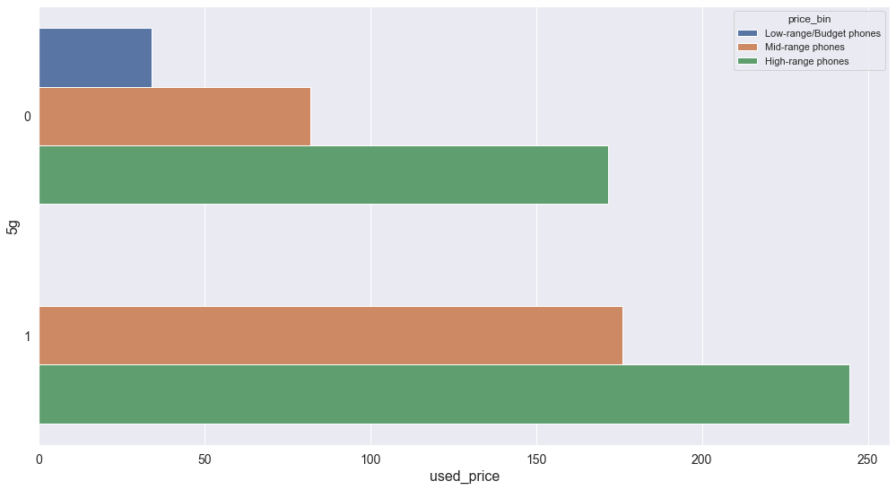

```python
# used_price by 5G availablility and price_bin

plt.figure(figsize=(17, 9))
sns.barplot(y="5g", x="used_price", data=phone, hue="price_bin", ci=None)
plt.xlabel("used_price", fontsize=16)
plt.ylabel("5g", fontsize=16)
plt.xticks(fontsize=14)
plt.yticks(fontsize=14)
plt.show()
```

#### Observations

- The above two graphs on 4G and 5G availability in the used phones indicate:
  - 5G is not available in low-range/budget phones
  - Price of high-range 5G phones > Price of high-range 4G phones

# Data Preprocessing (Contd.)

## 5. Data preparation for modeling

- We want to predict the used_price of the phone.
- Before proceeding to build a model, categorical features need to be encoded
- **One-hot encoding** is being employed to catgorical variables so that arithmetic can be done on these variables and they can be entered into the model.
- Next, we'll split the data into train and test to be able to evaluate the model that we build on the train data.
- Th next step would be building a Linear Regression model using the train data and then check it's performance.

```python
# defining X and y variables

X = phone.drop(["used_price", "brand_name"], axis=1)
y = phone["used_price"]

print(X.head())
print(y.head())
```

```
        os  screen_size 4g 5g  main_camera_mp  selfie_camera_mp  int_memory  \
0  Android         8.75  1  0            13.0               5.0        64.0
1  Android         8.75  1  1            13.0              16.0       128.0
2  Android         8.75  1  1            13.0               8.0       128.0
3  Android         8.75  1  1            13.0               8.0        64.0
4  Android         6.19  1  0            13.0               8.0        64.0

   ram  battery  weight  release_year  days_used                price_bin
0  3.0   3020.0   146.0          2020        127  Low-range/Budget phones
1  8.0   4300.0   213.0          2020        325         Mid-range phones
2  8.0   4200.0   213.0          2020        162        High-range phones
3  6.0   6850.0   250.0          2020        345         Mid-range phones
4  3.0   5000.0   185.0          2020        293         Mid-range phones
0     86.9600
1    161.4900
2    247.1925
3    180.2300
4    103.8000
Name: used_price, dtype: float64
```

```python
# One-hot encoding for categorical variables

X = pd.get_dummies(
    X, columns=X.select_dtypes(include=["category"]).columns.tolist(), drop_first=True
)
X.head()
```

|  | screen_size | main_camera_mp | selfie_camera_mp | int_memory | ram | battery | weight | release_year | days_used | os_Others | os_Windows | os_iOS | 4g_1 | 5g_1 | price_bin_Mid-range phones | price_bin_High-range phones |
| --- | --- | --- | --- | --- | --- | --- | --- | --- | --- | --- | --- | --- | --- | --- | --- | --- |
| 0 | 8.75 | 13.0 | 5.0 | 64.0 | 3.0 | 3020.0 | 146.0 | 2020 | 127 | 0 | 0 | 0 | 1 | 0 | 0 | 0 |
| 1 | 8.75 | 13.0 | 16.0 | 128.0 | 8.0 | 4300.0 | 213.0 | 2020 | 325 | 0 | 0 | 0 | 1 | 1 | 1 | 0 |
| 2 | 8.75 | 13.0 | 8.0 | 128.0 | 8.0 | 4200.0 | 213.0 | 2020 | 162 | 0 | 0 | 0 | 1 | 1 | 0 | 1 |
| 3 | 8.75 | 13.0 | 8.0 | 64.0 | 6.0 | 6850.0 | 250.0 | 2020 | 345 | 0 | 0 | 0 | 1 | 1 | 1 | 0 |
| 4 | 6.19 | 13.0 | 8.0 | 64.0 | 3.0 | 5000.0 | 185.0 | 2020 | 293 | 0 | 0 | 0 | 1 | 0 | 1 | 0 |

```python
# checking the shape of the dataset

X.shape
```

```
(3571, 16)
```

```python
# splitting the data in 70:30 ratio for train to test data

x_train, x_test, y_train, y_test = train_test_split(
    X, y, test_size=0.3, random_state=42
)
```

```python
# checking the shape of the train and test dataset

print("Number of rows in train data =", x_train.shape[0])
print("Number of rows in test data =", x_test.shape[0])
```

```
Number of rows in train data = 2499
Number of rows in test data = 1072
```

**Our data is now ready to be input into the regression model.**

# Building a Linear Regression model

```python
# Building and fitting the model on the train data (70% of the whole data)

linearregression = LinearRegression()
linearregression.fit(x_train, y_train)
```

```
LinearRegression()
```

```python
# Checking the coefficients and intercept of the model using sklearn

coef_df = pd.DataFrame(
    np.append(linearregression.coef_, linearregression.intercept_),
    index=x_train.columns.tolist() + ["Intercept"],
    columns=["Coefficients"],
)

coef_df
```

|  | Coefficients |
| --- | --- |
| screen_size | 0.453527 |
| main_camera_mp | 0.628664 |
| selfie_camera_mp | 1.022010 |
| int_memory | 0.054290 |
| ram | 3.246197 |
| battery | 0.001165 |
| weight | 0.040918 |
| release_year | -1.308177 |
| days_used | -0.090097 |
| os_Others | -9.439057 |
| os_Windows | -3.164128 |
| os_iOS | 36.952157 |
| 4g_1 | -0.376978 |
| 5g_1 | 19.087207 |
| price_bin_Mid-range phones | 34.939144 |
| price_bin_High-range phones | 110.460172 |
| Intercept | 2706.242700 |

# Model performance evaluation

- Let's check the performance of the model using different metrics - RMSE, MAE, and 𝑅2.
- A function is being defined to calculate MAPE and adjusted 𝑅2.

```python
# function to compute adjusted R-squared
def adj_r2_score(predictors, targets, predictions):
    r2 = r2_score(targets, predictions)
    n = predictors.shape[0]
    k = predictors.shape[1]
    return 1 - ((1 - r2) * (n - 1) / (n - k - 1))


# function to compute MAPE
def mape_score(targets, predictions):
    return np.mean(np.abs(targets - predictions) / targets) * 100


# function to compute different metrics to check performance of a regression model
def model_performance_regression(model, predictors, target):
    """
    Function to compute different metrics to check regression model performance

    model: regressor
    predictors: independent variables
    target: dependent variable
    """

    # predicting using the independent variables
    pred = model.predict(predictors)

    r2 = r2_score(target, pred)  # to compute R-squared
    adjr2 = adj_r2_score(predictors, target, pred)  # to compute adjusted R-squared
    rmse = np.sqrt(mean_squared_error(target, pred))  # to compute RMSE
    mae = mean_absolute_error(target, pred)  # to compute MAE
    mape = mape_score(target, pred)  # to compute MAPE

    # Creating a dataframe of metrics
    # Function which will print out all the above metrics in one go
    df_perf = pd.DataFrame(
        {
            "RMSE": rmse,
            "MAE": mae,
            "R-squared": r2,
            "Adj. R-squared": adjr2,
            "MAPE": mape,
        },
        index=[0],
    )

    return df_perf
```

```python
# checking model performance on train set (seen 70% data)

print("Training Performance\n")
linearregression_train_perf = model_performance_regression(
    linearregression, x_train, y_train
)
linearregression_train_perf
```

```
Training Performance
```

|  | RMSE | MAE | R-squared | Adj. R-squared | MAPE |
| --- | --- | --- | --- | --- | --- |
| 0 | 24.079748 | 18.371726 | 0.866523 | 0.865662 | 28.754269 |

```python
# checking model performance on test set (seen 30% data)

print("Test Performance\n")
linearregression_test_perf = model_performance_regression(
    linearregression, x_test, y_test
)
linearregression_test_perf
```

```
Test Performance
```

|  | RMSE | MAE | R-squared | Adj. R-squared | MAPE |
| --- | --- | --- | --- | --- | --- |
| 0 | 23.31909 | 18.017848 | 0.877514 | 0.875656 | 26.465947 |

### Linear Regression Model using Statsmodels

**Sklearn does help us look at coefficients but to understand the significance of variables, linear regression is being run using statsmodels as well.**

```python
# unlike sklearn, statsmodels does not add a constant to the data on its own
# we have to add the constant manually
x_train1 = sm.add_constant(x_train)
# adding constant to the test data
x_test1 = sm.add_constant(x_test)

olsmod0 = sm.OLS(y_train, x_train1).fit()
print(olsmod0.summary())
```

```
                            OLS Regression Results
==============================================================================
Dep. Variable:             used_price   R-squared:                       0.867
Model:                            OLS   Adj. R-squared:                  0.866
Method:                 Least Squares   F-statistic:                     1007.
Date:                Sat, 21 Aug 2021   Prob (F-statistic):               0.00
Time:                        04:45:34   Log-Likelihood:                -11496.
No. Observations:                2499   AIC:                         2.303e+04
Df Residuals:                    2482   BIC:                         2.313e+04
Df Model:                          16
Covariance Type:            nonrobust
===============================================================================================
                                  coef    std err          t      P>|t|      [0.025      0.975]
-----------------------------------------------------------------------------------------------
const                        2706.2427    876.545      3.087      0.002     987.407    4425.078
screen_size                     0.4535      0.529      0.857      0.391      -0.584       1.491
main_camera_mp                  0.6287      0.138      4.546      0.000       0.357       0.900
selfie_camera_mp                1.0220      0.113      9.064      0.000       0.801       1.243
int_memory                      0.0543      0.006      8.736      0.000       0.042       0.066
ram                             3.2462      0.451      7.194      0.000       2.361       4.131
battery                         0.0012      0.001      1.597      0.110      -0.000       0.003
weight                          0.0409      0.021      1.976      0.048       0.000       0.082
release_year                   -1.3082      0.435     -3.010      0.003      -2.161      -0.456
days_used                      -0.0901      0.003    -29.282      0.000      -0.096      -0.084
os_Others                      -9.4391      2.350     -4.016      0.000     -14.048      -4.830
os_Windows                     -3.1641      3.564     -0.888      0.375     -10.152       3.824
os_iOS                         36.9522      4.163      8.877      0.000      28.789      45.115
4g_1                           -0.3770      1.498     -0.252      0.801      -3.315       2.561
5g_1                           19.0872      3.160      6.040      0.000      12.890      25.284
price_bin_Mid-range phones     34.9391      1.447     24.153      0.000      32.103      37.776
price_bin_High-range phones   110.4602      1.905     57.975      0.000     106.724     114.196
==============================================================================
Omnibus:                      169.375   Durbin-Watson:                   1.990
Prob(Omnibus):                  0.000   Jarque-Bera (JB):              271.384
Skew:                           0.530   Prob(JB):                     1.17e-59
Kurtosis:                       4.217   Cond. No.                     6.95e+06
==============================================================================

Notes:
[1] Standard Errors assume that the covariance matrix of the errors is correctly specified.
[2] The condition number is large, 6.95e+06. This might indicate that there are
strong multicollinearity or other numerical problems.
```

#### Observations

- Negative values of the coefficient show that used_price decreases with the increase of corresponding attribute value. This holds true for **release_year, days_used, os_others, os_Windows and 4g_1.**
- Positive values of the coefficient show that used_price increases with the increase of corresponding attribute value. This holds true for **screen_size, main_camera_mp, selfie_camera_mp, int_memory, ram, battery, weight, os_iOS, 5g_1, price_bin_Mid-range phones and price_bin_High-range phones.**
- p-value of a variable indicates if the variable is significant or not. If we consider the significance level to be 0.05 (5%), then any variable with a p-value less than 0.05 would be considered significant. Here, **screen_size, battery, os_Windows and 4g_1 are not significant.**
- There could be multicollinearity between predictor variables, which will affect the p-values. So, we need to deal with multicollinearity and check the other assumptions of linear regression first, and then look at the p-values.